# Hierarchical analyses of avian community biogeography in the Afromontane highlands

Jacob C. Cooper

9/17/2021

# 1 Introduction

This exercise is designed to determine relationships between different Afromontane regions using different species lists and different taxonomic levels.

# 2 Setting up the code

I hide it here, but note that I declare my filepath for the rest of the document.

### Required *R* Packages:

```r
library(tidyverse)
```

```r
library(ggplot2)
```

### Setting up the dataset:

Note here that I am reducing the presence-absence matrix down to the final presence-absence matrix used in the study (v2).

```r
x=as.data.frame(read_csv(paste0(filepath,"TableS1-Species_PAM_v2.csv")))
summary(x)
```

```
##   From Bowie        From Dowsett         Exclude             Clements
##  Length:825         Length:825         Length:825         Min.   :  329
##  Class :character   Class :character   Class :character   1st Qu.:21949
##  Mode  :character   Mode  :character   Mode  :character   Median :23896
##                                                           Mean   :22705
##                                                           3rd Qu.:28639
##                                                           Max.   :31354
##
##     Genus           Superspecies         Species             Group
##  Length:825         Length:825         Length:825         Length:825
##  Class :character   Class :character   Class :character   Class :character
##  Mode  :character   Mode  :character   Mode  :character   Mode  :character
##
##
##
##
##   Subspecies        Upper Guinea Highlands     Bioko      Mt. Cameroon
##  Length:825         Min.   :1              Min.   :1     Min.   :1
##  Class :character   1st Qu.:1              1st Qu.:1     1st Qu.:1
##  Mode  :character   Median :1              Median :1     Median :1
##                     Mean   :1              Mean   :1     Mean   :1
##                     3rd Qu.:1              3rd Qu.:1     3rd Qu.:1
##                     Max.   :1              Max.   :1     Max.   :1
##                     NA's   :812            NA's   :789   NA's   :775
##  Cameroon Highlands Bamenda & Adamawa   Monte Alen      Lendu       West Rift
##  Min.   :1          Min.   :1         Min.   :1     Min.   :1     Min.   :1
##  1st Qu.:1          1st Qu.:1         1st Qu.:1     1st Qu.:1     1st Qu.:1
##  Median :1          Median :1         Median :1     Median :1     Median :1
##  Mean   :1          Mean   :1         Mean   :1     Mean   :1     Mean   :1
##  3rd Qu.:1          3rd Qu.:1         3rd Qu.:1     3rd Qu.:1     3rd Qu.:1
##  Max.   :1          Max.   :1         Max.   :1     Max.   :1     Max.   :1
##  NA's   :773        NA's   :761       NA's   :819   NA's   :756   NA's   :693
##     Rwenzori     East Rift       Kabobo       Marungu        Mahale
##  Min.   :1     Min.   :1     Min.   :1     Min.   :1     Min.   :1
##  1st Qu.:1     1st Qu.:1     1st Qu.:1     1st Qu.:1     1st Qu.:1
##  Median :1     Median :1     Median :1     Median :1     Median :1
##  Mean   :1     Mean   :1     Mean   :1     Mean   :1     Mean   :1
##  3rd Qu.:1     3rd Qu.:1     3rd Qu.:1     3rd Qu.:1     3rd Qu.:1
##  Max.   :1     Max.   :1     Max.   :1     Max.   :1     Max.   :1
##  NA's   :727   NA's   :705   NA's   :759   NA's   :792   NA's   :798
```

[output cut: 49 more lines]

```
##  Min.   :1     Min.   :1     Min.   :1     Min.   :1
##  1st Qu.:1     1st Qu.:1     1st Qu.:1     1st Qu.:1
##  Median :1     Median :1     Median :1     Median :1
##  Mean   :1     Mean   :1     Mean   :1     Mean   :1
##  3rd Qu.:1     3rd Qu.:1     3rd Qu.:1     3rd Qu.:1
##  Max.   :1     Max.   :1     Max.   :1     Max.   :1
##  NA's   :771   NA's   :766   NA's   :757   NA's   :776
##  Central African Plateau (Zambia)     Angola    Rondo Plateau    Mayombe
##  Min.   :1                        Min.   :1     Min.   :1     Min.   :1
##  1st Qu.:1                        1st Qu.:1     1st Qu.:1     1st Qu.:1
##  Median :1                        Median :1     Median :1     Median :1
##  Mean   :1                        Mean   :1     Mean   :1     Mean   :1
##  3rd Qu.:1                        3rd Qu.:1     3rd Qu.:1     3rd Qu.:1
##  Max.   :1                        Max.   :1     Max.   :1     Max.   :1
##  NA's   :792                      NA's   :766   NA's   :817   NA's   :821
```

```r
x.1=x[,1:9]
x.2=x[,-c(1:9)]

x.2[is.na(x.2)]=0

x=cbind(x.1,x.2)

colSums(x[,-c(1:9)])
```

```
##           Upper Guinea Highlands                            Bioko
##                               13                               36
##                     Mt. Cameroon               Cameroon Highlands
##                               50                               52
##                Bamenda & Adamawa                       Monte Alen
##                               64                                6
##                            Lendu                        West Rift
##                               69                              132
##                         Rwenzori                        East Rift
##                               98                              120
##                           Kabobo                          Marungu
##                               66                               33
##                           Mahale                North Somali Mtns
##                               27                               20
##                         Djibouti                    West Ethiopia
##                                4                              103
##                    East Ethiopia                      S Eth-N Ken
##                               93                               34
##                          Imatong                            Elgon
##                               63                               95
##                       West Kenya                   Kenya-Aberdare
##                              108                              106
##                       Ngorongoro                             Meru
##                               84                               84
##                      Kilimanjaro                            Taita
##                               82                               43
##                             Pare                         Usambara
##                               61                               81
##                             Nguu                            Nguru
##                               41                               46
##                          Ukaguru                           Rubeho
##                               53                               51
##                          Uluguru                         Udzungwa
##                               77                               88
##               Southern Highlands                            Nyika
##                               82                               81
##                        Kaningina                     Dedza-Salima
##                               60                               48
##                            Zomba                           Thyolo
##                               50                               50
##                          Mulanje                           Namuli
##                               49                               41
##                        Gorongosa                      Chimanimani
##                               33                               54
##                    N Drakensberg                    S Drakensberg
##                               59                               68
##              Cape Fold Mountains Central African Plateau (Zambia)
##                               49                               33
##                           Angola                    Rondo Plateau
##                               59                                8
##                          Mayombe
##                                4
```

```r
colnames(x)
```

```
##  [1] "From Bowie"                       "From Dowsett"
##  [3] "Exclude"                          "Clements"
##  [5] "Genus"                            "Superspecies"
##  [7] "Species"                          "Group"
##  [9] "Subspecies"                       "Upper Guinea Highlands"
## [11] "Bioko"                            "Mt. Cameroon"
## [13] "Cameroon Highlands"               "Bamenda & Adamawa"
## [15] "Monte Alen"                       "Lendu"
## [17] "West Rift"                        "Rwenzori"
## [19] "East Rift"                        "Kabobo"
## [21] "Marungu"                          "Mahale"
## [23] "North Somali Mtns"                "Djibouti"
## [25] "West Ethiopia"                    "East Ethiopia"
## [27] "S Eth-N Ken"                      "Imatong"
## [29] "Elgon"                            "West Kenya"
## [31] "Kenya-Aberdare"                   "Ngorongoro"
## [33] "Meru"                             "Kilimanjaro"
## [35] "Taita"                            "Pare"
## [37] "Usambara"                         "Nguu"
## [39] "Nguru"                            "Ukaguru"
## [41] "Rubeho"                           "Uluguru"
## [43] "Udzungwa"                         "Southern Highlands"
## [45] "Nyika"                            "Kaningina"
## [47] "Dedza-Salima"                     "Zomba"
## [49] "Thyolo"                           "Mulanje"
## [51] "Namuli"                           "Gorongosa"
## [53] "Chimanimani"                      "N Drakensberg"
## [55] "S Drakensberg"                    "Cape Fold Mountains"
## [57] "Central African Plateau (Zambia)" "Angola"
## [59] "Rondo Plateau"                    "Mayombe"
```

```r
x2=x

# reformat names to be hierarchical

x2$Superspecies=paste(x2$Genus,x2$Superspecies)
x2$Species=paste(x2$Superspecies,x2$Species)
x2$Group=paste(x2$Species,x2$Group)
x2$Subspecies=paste(x2$Group,x2$Subspecies)
```

## 2.2 Remove Satellite Regions

For this iteration, I am going to remove satellite regions that can conflate analyses and group depauperate regions together.

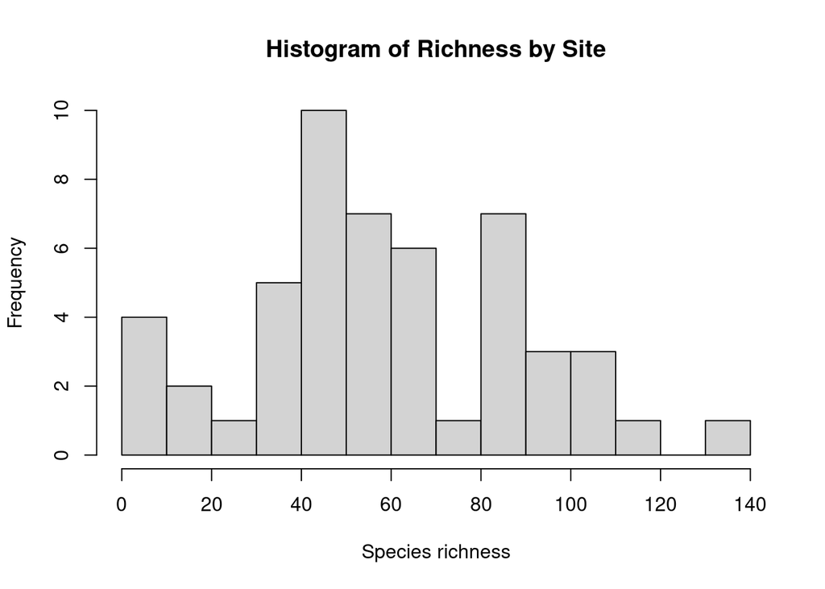

```r
hist(colSums(x2[,10:ncol(x2)]),breaks = 15,
     main = "Histogram of Richness by Site",
     xlab = "Species richness")
```

```r
which(colSums(x2[,10:ncol(x2)])<34)
```

```
##           Upper Guinea Highlands                       Monte Alen
##                                1                                6
##                          Marungu                           Mahale
##                               12                               13
##                North Somali Mtns                         Djibouti
##                               14                               15
##                        Gorongosa Central African Plateau (Zambia)
##                               43                               48
##                    Rondo Plateau                          Mayombe
##                               50                               51
```

These are the regions that are often grouped together as the *satellite regions* clade. Thus, we are removing them to improve the clustering ability and to better analyze the regions with better represented communities (that are thus more inferrable for relationships). **Note**: I am making an exception for Gorongosa because this region was classifiable, despite its more limited species community. This was also the only point that would not be classified as a ‘satellite’ region.

Note the following sites were removed from a previous iteration based on lack of confidence in species’ lists:

1. Mahenge
2. Mbulu

```r
x2=x2%>%select(-`Upper Guinea Highlands`,-`Monte Alen`,
               -Marungu,-Mahale,-`North Somali Mtns`,
               -Djibouti,-`Central African Plateau (Zambia)`,
               -`Rondo Plateau`,-Mayombe)

x2=x2[-which(rowSums(x2[,10:ncol(x2)])==0),]
# save alternate version without these localities
write_csv(x2,file = paste0(filepath,"TableS1_v2.csv"),col_names = T)
```

Now we need to reformat the metadata file as well.

```r
locs=colnames(x2[,-c(1:9)])

meta=read_csv(paste0(filepath,"locality_metadata.csv"))
meta2=meta[which(meta$Locality%in%locs),]

write_csv(meta2,file=paste0(filepath,"locality_metadata_v2.csv"))
```

# 3 Taxa overview

With the removal of the aforemention ‘satellite’ regions and other poorly sampled sites, we have the resulting number of species, with change denoted (if any). **These are the official numbers for this study**:

| Source | Genus | Superspecies | Species | Group | Subspecies |
| --- | --- | --- | --- | --- | --- |
| Dowsett (1986) | 109 | 207 | 261 | 334 | 532 |
| Bowie (2003) | 123 | 250 | 309 | 393 | 627 |
| This study | 130 | 287 | 350 | 442 | 725 |